# Recreating a Professional Visualization

## Load packages

```r
library(data.table)
library(plyr)
library(ggplot2)
library(dplyr)
```

## Load data

The data was supplied by the “Data Science and Machine Learning Bootcamp with R” Udemy course:

```r
plot_data <- fread("Economist_Assignment_Data.csv", na.strings = "", showProgress = FALSE) %>% tbl_df
```

## Clean data

Check the data to make sure it is in a good format for plotting:

```r
summary(plot_data)
```

```
##       V1              Country             HDI.Rank           HDI
##  Length:173         Length:173         Min.   :  1.00   Min.   :0.2860
##  Class :character   Class :character   1st Qu.: 47.00   1st Qu.:0.5090
##  Mode  :character   Mode  :character   Median : 96.00   Median :0.6980
##                                        Mean   : 95.28   Mean   :0.6581
##                                        3rd Qu.:143.00   3rd Qu.:0.7930
##                                        Max.   :187.00   Max.   :0.9430
##       CPI           Region
##  Min.   :1.500   Length:173
##  1st Qu.:2.500   Class :character
##  Median :3.200   Mode  :character
##  Mean   :4.052
##  3rd Qu.:5.100
##  Max.   :9.500
```

Everything looks good except for `Region`. This variable will be converted to a factor variable because it is categorical:

```r
plot_data$Region <- factor(plot_data$Region)
```

The `Region` variable also has to be revalued and reordered to have the same names and ordering:

```r
plot_data$Region <- revalue(plot_data$Region, c("EU W. Europe" = "OECD" , "Americas" = "Americas", "Asia Pacific" = "Asia & Oceania", "East EU Cemt Asia" = "Central & Eastern Europe", "MENA" = "Middle East & north Africa", "SSA" = "Sub-Saharan Africa"))
plot_data$Region <- factor(plot_data$Region, levels(plot_data$Region)[c(4, 1:3, 5:6)])
```

Other miscellaneous changes had to be made to the data since the source data was not labeled the exact same as *The Economist* plot:

```r
plot_data[plot_data$Country == "United States",]$Country <- "US"
plot_data[plot_data$Country == "Romania",]$CPI <- 11 # Make it disappear (Could be different data for why its missing)
plot_data[plot_data$Country == "Australia",]$Region <- "OECD"
plot_data[plot_data$Country == "Canada",]$Region <- "OECD"
plot_data[plot_data$Country == "Chile",]$Region <- "OECD"
plot_data[plot_data$Country == "Cyprus",]$Region <- "Central & Eastern Europe"
plot_data[plot_data$Country == "Israel",]$Region <- "OECD"
plot_data[plot_data$Country == "Japan",]$Region <- "OECD"
plot_data[plot_data$Country == "Korea (South)",]$Region <- "OECD"
plot_data[plot_data$Country == "Lithuania",]$Region <- "Central & Eastern Europe"
plot_data[plot_data$Country == "Malta",]$Region <- "Central & Eastern Europe"
plot_data[plot_data$Country == "Mexico",]$Region <- "OECD"
plot_data[plot_data$Country == "New Zealand",]$Region <- "OECD"
plot_data[plot_data$Country == "Turkey",]$Region <- "OECD"
plot_data[plot_data$Country == "US",]$Region <- "OECD"
plot_data[plot_data$Country == "Sudan",]$Region <- "Middle East & north Africa"
```

## Recreate the Plot

### Geom_point layer and settings

First, the data is plotted using a `geom_point` layer and colored according to each country’s region. Other aesthetic settings were included to make the points look like the colored circles in the reference plot:

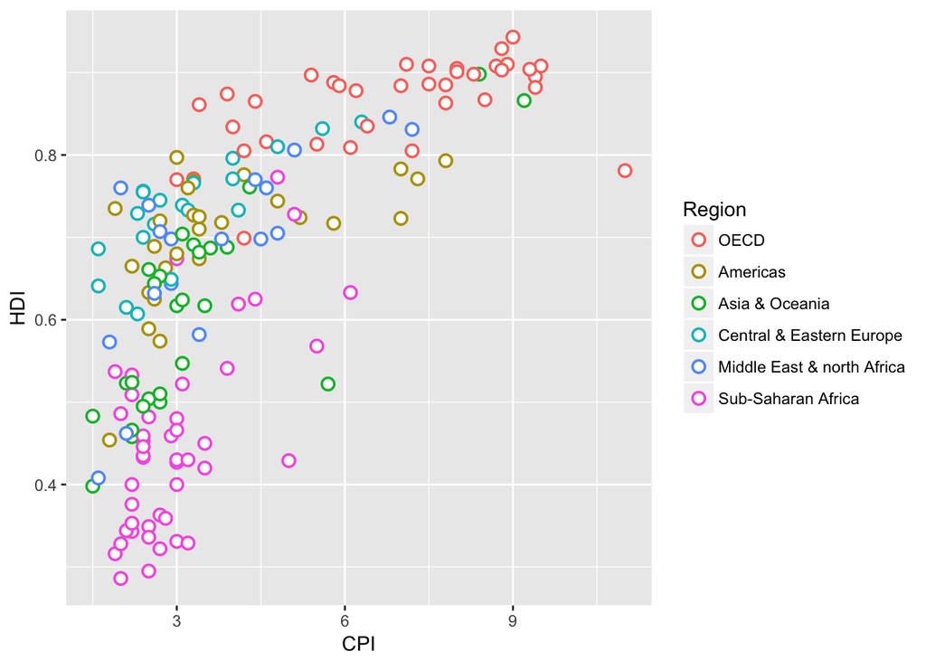

```r
ggplot(plot_data, aes(x = CPI, y = HDI, color = Region)) +
    geom_point(size = 2.5, shape = 21, fill = "white", stroke = 1)
```

```r
finished_layers <- list(geom_point(size = 2.5, shape = 21, fill = "white", stroke = 1))
```

### Geom_smooth layer and settings

A regression line for the log(CPI) is added to the plot using `geom_smooth`, resized, colored red, and extended to the full range of the plot:

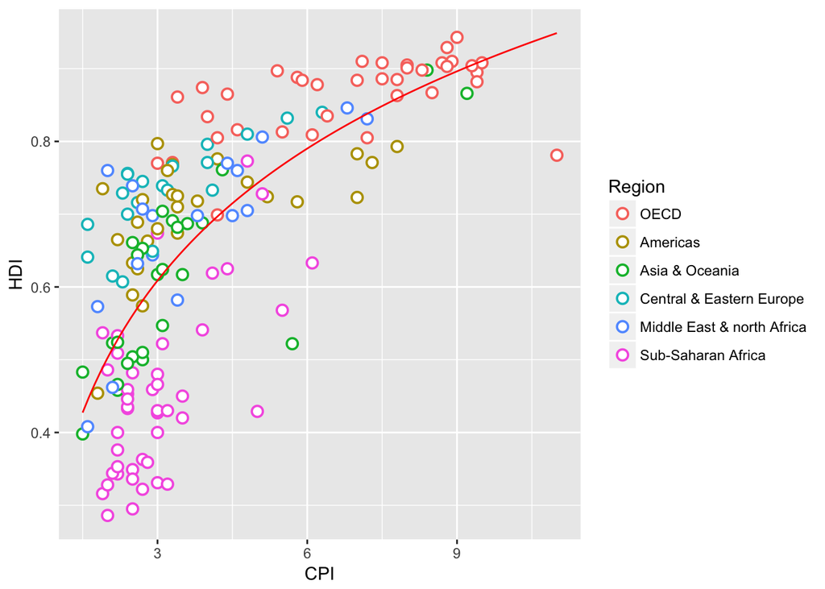

```r
ggplot(plot_data, aes(x = CPI, y = HDI, color = Region)) +
    finished_layers +
    geom_smooth(method= "lm", formula = y ~ log(x), se = FALSE, color = "red", size = 0.5, fullrange = TRUE)
```

```r
finished_layers <- list(finished_layers, geom_smooth(method= "lm", formula = y ~ log(x), se = FALSE, color = "red", size = 0.5, fullrange = TRUE))
```

### Geom_text layer and settings

Next, the labels are added to the plot using `geom_text`, resized, and then nudged into the right positions:

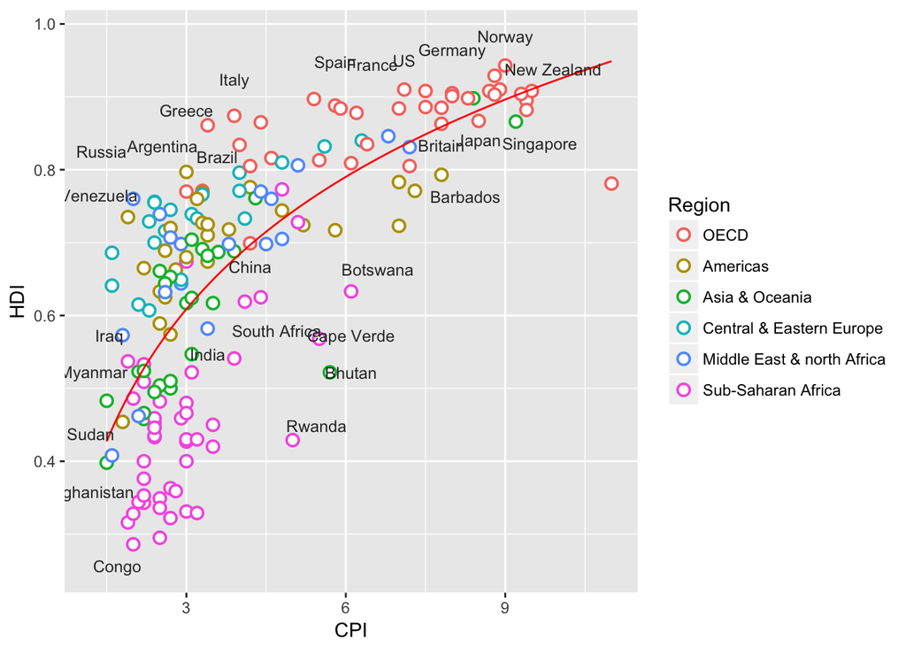

```r
pointsToLabel <- c("Russia", "Venezuela", "Iraq", "Myanmar", "Sudan",
                   "Afghanistan", "Congo", "Greece", "Argentina", "Brazil",
                   "India", "Italy", "China", "South Africa", "Spain",
                   "Botswana", "Cape Verde", "Bhutan", "Rwanda", "France",
                   "US", "Germany", "Britain", "Barbados", "Norway", "Japan",
                   "New Zealand", "Singapore")
ggplot(plot_data, aes(x = CPI, y = HDI, color = Region)) +
    finished_layers +
    geom_text(aes(label = Country), color = "gray20", data = subset(plot_data, Country %in% pointsToLabel), check_overlap = FALSE, size = (5/14)*9,
              nudge_x = c(-0.30, -0.450, 00.45, 0.40, 0.50, -0.220, 00.00, 0.600, 00.60, -0.30, -0.50, 0.00, -0.40, 0.3, -0.25, 0.00, 00.50, -0.25, 0.40, 0.00, -1.00, 0.45, 00.45, 00.60, -0.40, -0.40, 0.00, -0.55),
              nudge_y = c(-0.04, 00.035, -0.03, 0.00, 0.03, 00.100, -0.03, 0.005, -0.02, -0.03, 00.06, 0.06, 00.02, 0.0, 00.00, 0.05, -0.06, 00.04, 0.03, 0.04, 00.07, 0.02, -0.03, -0.04, 00.07, 00.03, 0.04, 00.03))
```

```r
finished_layers <- list(finished_layers, geom_text(aes(label = Country), color = "gray20", data = subset(plot_data, Country %in% pointsToLabel), check_overlap = FALSE, size = (5/14)*9,
              nudge_x = c(-0.30, -0.450, 00.45, 0.40, 0.50, -0.220, 00.00, 0.600, 00.60, -0.30, -0.50, 0.00, -0.40, 0.3, -0.25, 0.00, 00.50, -0.25, 0.40, 0.00, -1.00, 0.45, 00.45, 00.60, -0.40, -0.40, 0.00, -0.55),
              nudge_y = c(-0.04, 00.035, -0.03, 0.00, 0.03, 00.100, -0.03, 0.005, -0.02, -0.03, 00.06, 0.06, 00.02, 0.0, 00.00, 0.05, -0.06, 00.04, 0.03, 0.04, 00.07, 0.02, -0.03, -0.04, 00.07, 00.03, 0.04, 00.03)))
```

### Geom_segments and settings

The line segments needed for some of the countries are then added to the plot using `geom_segment`:

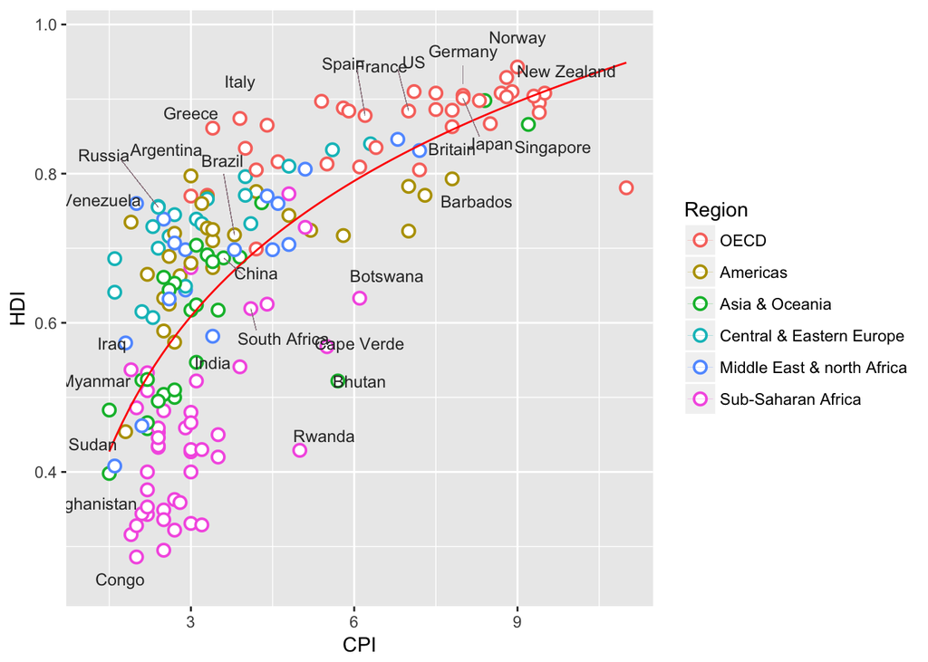

```r
ggplot(plot_data, aes(x = CPI, y = HDI, color = Region)) +
    finished_layers +
    geom_segment(x = 1.7, y = 0.82, xend = 2.4, yend = 0.755, size = 0.01, alpha = 0.7) + # Russia
    geom_segment(x = 3.6, y = 0.80, xend = 3.8, yend = 0.718, size = 0.01, alpha = 0.7) + # Brazil
    geom_segment(x = 3.95, y = 0.665, xend = 3.6, yend = 0.687, size = 0.01, alpha = 0.7) + # China
    geom_segment(x = 4.2, y = 0.59, xend = 4.1, yend = 0.619, size = 0.01, alpha = 0.7) + # South Africa
    geom_segment(x = 6.05, y = 0.94, xend = 6.2, yend = 0.878, size = 0.01, alpha = 0.7) + # Spain
    geom_segment(x = 6.8, y = 0.94, xend = 7, yend = 0.884, size = 0.01, alpha = 0.7) + # France
    geom_segment(x = 8, y = 0.945, xend = 8, yend = 0.92, size = 0.01, alpha = 0.7) + # Germany
    geom_segment(x = 8.3, y = 0.85, xend = 8, yend = 0.901, size = 0.01, alpha = 0.7) # Japan
```

```r
finished_layers <- list(finished_layers, geom_segment(x = 1.7, y = 0.82, xend = 2.4, yend = 0.755, size = 0.01, alpha = 0.7), geom_segment(x = 3.6, y = 0.80, xend = 3.8, yend = 0.718, size = 0.01, alpha = 0.7),geom_segment(x = 3.95, y = 0.665, xend = 3.6, yend = 0.687, size = 0.01, alpha = 0.7), geom_segment(x = 4.2, y = 0.59, xend = 4.1, yend = 0.619, size = 0.01, alpha = 0.7), geom_segment(x = 6.05, y = 0.94, xend = 6.2, yend = 0.878, size = 0.01, alpha = 0.7), geom_segment(x = 6.8, y = 0.94, xend = 7, yend = 0.884, size = 0.01, alpha = 0.7), geom_segment(x = 8, y = 0.945, xend = 8, yend = 0.92, size = 0.01, alpha = 0.7), geom_segment(x = 8.3, y = 0.85, xend = 8, yend = 0.901, size = 0.01, alpha = 0.7))
```

### Scale color manual and settings

After that, the `Region` colors are recolored and the newlines are added for the long region names using `scale_color_manual`:

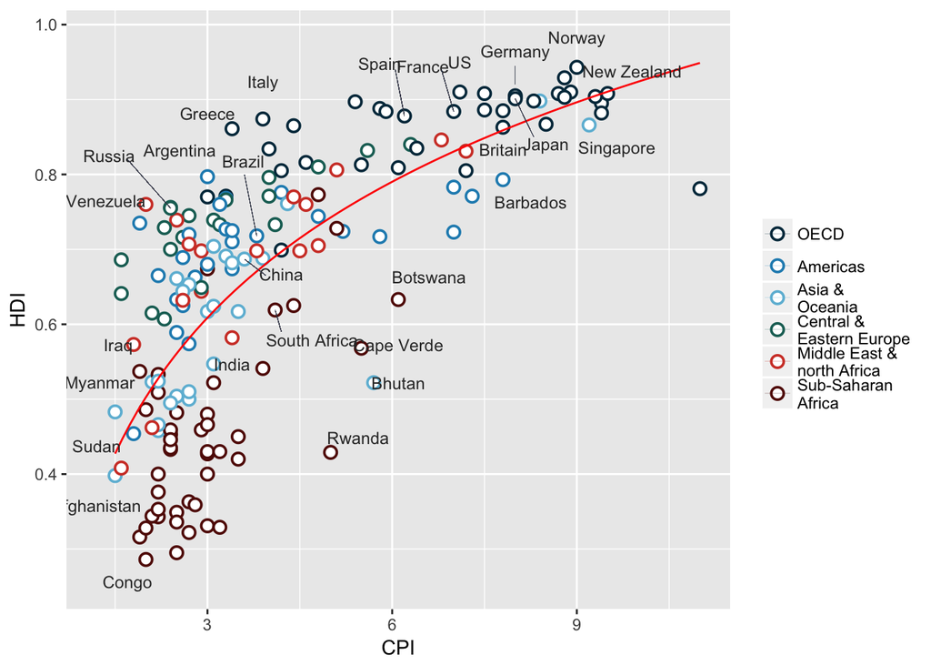

```r
ggplot(plot_data, aes(x = CPI, y = HDI, color = Region)) +
    finished_layers +
    scale_colour_manual(name = NULL,values = c('#01344A','#228DBD','#6DBBD8','#1B6E64','#D24131','#621107'), labels = c("OECD","Americas","Asia & \nOceania","Central & \nEastern Europe","Middle East & \nnorth Africa", "Sub-Saharan \nAfrica"))
```

```r
finished_layers <- list(finished_layers, scale_colour_manual(name = NULL,values = c('#01344A','#228DBD','#6DBBD8','#1B6E64','#D24131','#621107'), labels = c("OECD","Americas","Asia & \nOceania","Central & \nEastern Europe","Middle East & \nnorth Africa", "Sub-Saharan \nAfrica")))
```

### Scale continuous for both axes and settings

Both axes are extended to the proper lengths and breaks are set to match the reference plots using `scale_x_continous` and `scale_y_continous`:

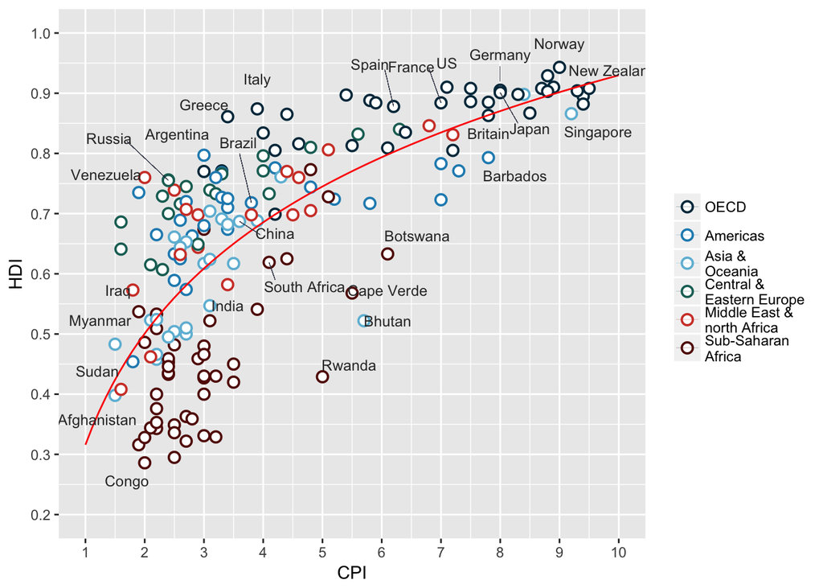

```r
ggplot(plot_data, aes(x = CPI, y = HDI, color = Region)) +
    finished_layers +
    scale_x_continuous(limits = c(1, 10), breaks = c(1:10)) +
    scale_y_continuous(limits = c(0.2,1), breaks = c(0.2, 0.3, 0.4, 0.5, 0.6, 0.7, 0.8, 0.9, 1.0))
```

```r
finished_layers <- list(finished_layers, scale_x_continuous(limits = c(1, 10), breaks = c(1:10)), scale_y_continuous(limits = c(0.2,1), breaks = c(0.2, 0.3, 0.4, 0.5, 0.6, 0.7, 0.8, 0.9, 1.0)))
```

### Plot labels and settings

The plot is then properly labeled using a `labs` layer:

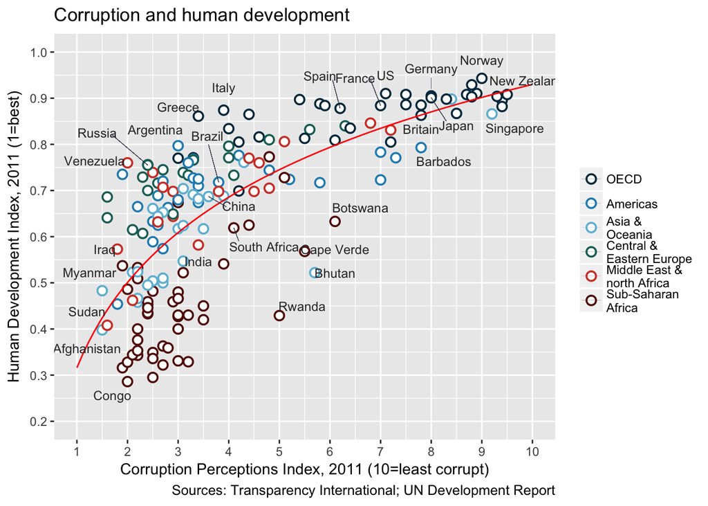

```r
ggplot(plot_data, aes(x = CPI, y = HDI, color = Region)) +
    finished_layers +
    labs(title = "Corruption and human development", y = "Human Development Index, 2011 (1=best)", x = "Corruption Perceptions Index, 2011 (10=least corrupt)", caption = "Sources: Transparency International; UN Development Report")
```

```r
finished_layers <- list(finished_layers, labs(title = "Corruption and human development", y = "Human Development Index, 2011 (1=best)", x = "Corruption Perceptions Index, 2011 (10=least corrupt)", caption = "Sources: Transparency International; UN Development Report"))
```

### Theme settings

Finally, the legend is moved to its proper position and shape using `guides` and `theme`. `theme_bw` is added to quickly change many theme settings to match the reference, and many more theme settings are set manually until the plot is complete:

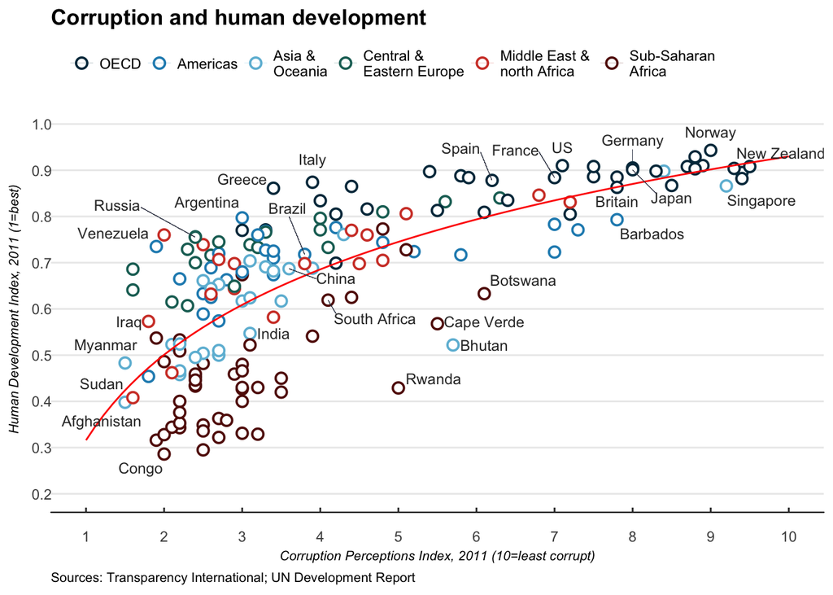

```r
ggplot(plot_data, aes(x = CPI, y = HDI, color = Region)) +
    finished_layers +
    guides(colour = guide_legend(nrow = 1)) +
    theme_bw() +
    theme(legend.position="top", panel.grid.major.x = element_blank(), panel.grid.minor.x = element_blank(), panel.grid.minor.y = element_blank(), legend.justification = 0, plot.title = element_text(face = 'bold'), axis.title = element_text(face = 'italic', size = 8), plot.caption = element_text(size = 8, hjust = 0), panel.border = element_blank(), axis.line.x = element_line(color = "black"), axis.ticks.y = element_blank(), axis.ticks.length=unit(-0.1, "cm"),axis.text.x = element_text(margin=unit(c(0.5,0.5,0,0), "cm")))
```

## Final comments

The recreated plot is very similar to the reference plot. Some of following key issues remain, but are not addressed:

- The correct font is missing. *The Economist* uses a different font than the default font used in ggplot. If the exact name of the font was known, it could be possible to fix this.
- Some of the longer country name labels feature a new line such as “South Africa”, but this was not fixed in the recreation.
- The R^2 value is missing from the legend
- It is clear that the supplied data is not exactly the same as what *The Economist* used, or they edited their data in an unknown way. Miscellaneous data errors and region classifications remain in the recreation compared to the reference plot.
- The x-axis looks a little different as its line extends past 1 in the recreation
- Other small spacing, margin, etc difference - of course, not everything is in the exact right spot since most positions were estimated.